# (More) Inference for numerical data

**Your reproducible lab report:** Before you get started, download the R Markdown template for this lab. Remember all of your code and answers go in this document:

```r
download("http://stat.duke.edu/courses/Fall15/sta101.002/rmd/lab7.Rmd", destfile = "lab7.Rmd")
```

## American salaries

Since 2005, the American Community Survey polls ~$3.5 million households yearly. We will work with a randon sample of 2000 observations from the 2012 ACS. You have already worked with this dataset once, as part of your application exercise. In this lab you get a chance to work with it a little more extensively.

```r
load(url("https://stat.duke.edu/~mc301/data/acs.RData"))
```

Below is the *codebook* for this dataset:

- `income`: Yearly income (wages and salaries)
- `employment`: Employment status, not in labor force, unemployed, or employed
- `hrs_work`: Weekly hours worked
- `race`: Race, White, Black, Asian, or other
- `age`: Age
- `gender`: gender, male or female
- `citizens`: Whether respondent is a US citizen or not
- `time_to_work`: Travel time to work
- `lang`: Language spoken at home, English or other
- `married`: Whether respondent is married or not
- `edu`: Education level, hs or lower, college, or grad
- `disability`: Whether respondent is disabled or not
- `birth_qrtr`: Quarter in which respondent is born, jan thru mar, apr thru jun, jul thru sep, or oct thru dec

Note that this dataset contains some people who are not in the labor force or not employed. First, let’s subset the dataset for those who are employed. We will call this new dataset `acs_emp`, short for “employed”. Remember that we use the `filter` function for subsetting the data based on attributes stored in a variable.

```r
acs_emp <- acs %>%
  filter(employment == "employed")
```

1. What percent of the original sample (`acs`) are employed?

Next let’s take a look at the income distribution by gender. The first step would be to create a visualization:

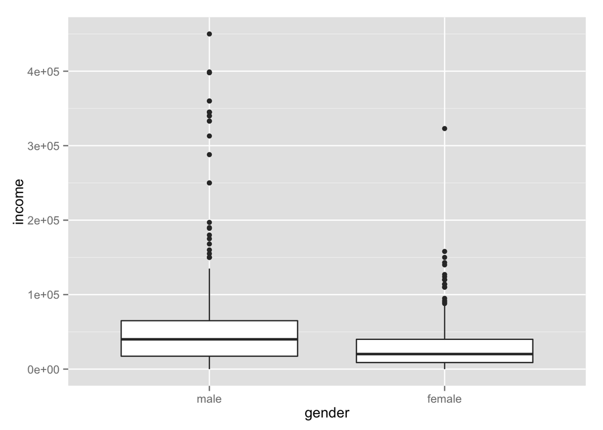

```r
qplot(y = income, x = gender, data = acs_emp, geom = "boxplot")
```

We can also obtain summary statistics such as means and standard deviations and sample sizes.

```r
gen_inc_stats <- acs_emp %>%
  group_by(gender) %>%
  summarise(xbar = mean(income), s = sd(income), n = n())
```

In this code chunk we not only calculated these summary statistics, but we also saved them in a new data frame called `gen_inc_stats`. Let’s view this data frame:

```r
gen_inc_stats
```

```
## Source: local data frame [2 x 4]
##
##   gender     xbar        s     n
##   (fctr)    (dbl)    (dbl) (int)
## 1   male 55887.23 68767.88   470
## 2 female 29243.70 32025.98   373
```

1. At a first glance how do the average incomes of males and females compare? Make sure to include the visualization and the summary statistics in your answer, and discuss/ interpret them.

Before you proceed, make sure to load the `inference` function. You might have this function already loaded in your console’s enviromment from last time, but not that in order to create a fully reproducible lab report you need to load it in your markdown document as well.

```r
load(url("https://stat.duke.edu/~mc301/R/fun/inference.RData"))
```

1. Construct a 95% confidence interval for the difference between the average incomes of males and females using the `inference` function, and interpret this interval.

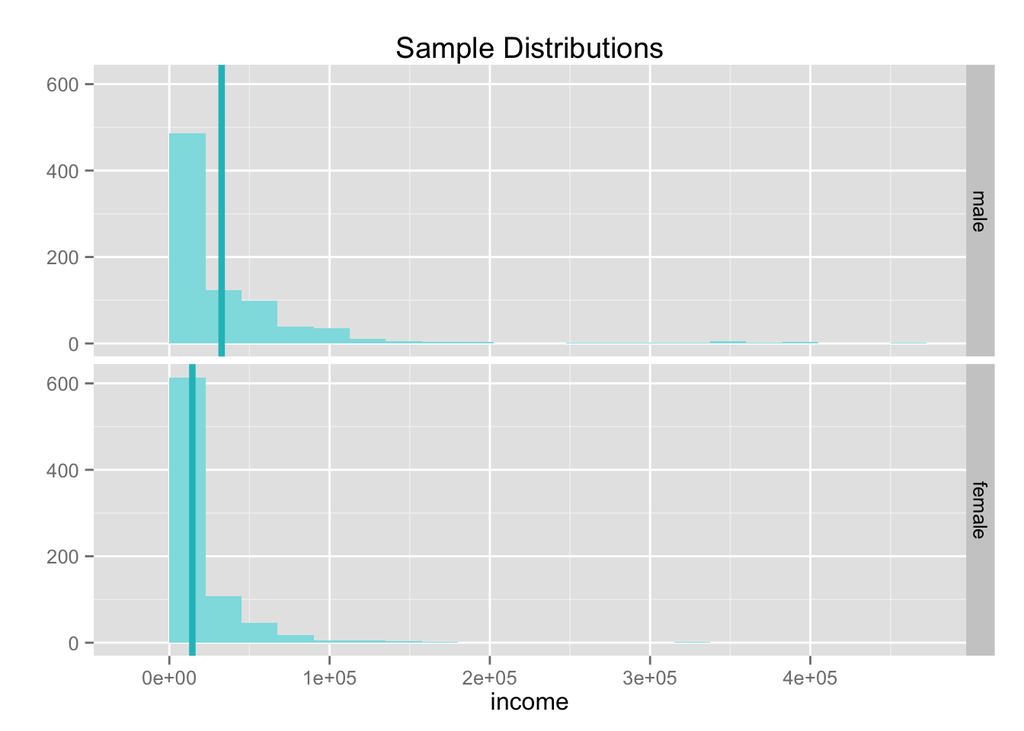

```
## $y_bar_diff
## [1] 18291.31
##
## $df
## [1] 800
##
## $SE
## [1] 2248.131
##
## $ME
## [1] 4412.931
##
## $CI
## [1] 13878.38 22704.24
```

```r
inference(data = acs, x = gender, y = income, type = "ci",
          method = "theoretical", statistic = "mean")
```

1. Based on this interval is there a statistically significant difference between the averege incomes of men and women? Why, or why not?
2. What is the significance level for the equivalent hypthesis test that evaluates whether there is a significant difference between average incomes of men and women.
3. Conduct this hypothesis test using the `inference` function, and interpret your results in context of the data and the research question. Do your results from the confidence interval and the hypothesis test agree?

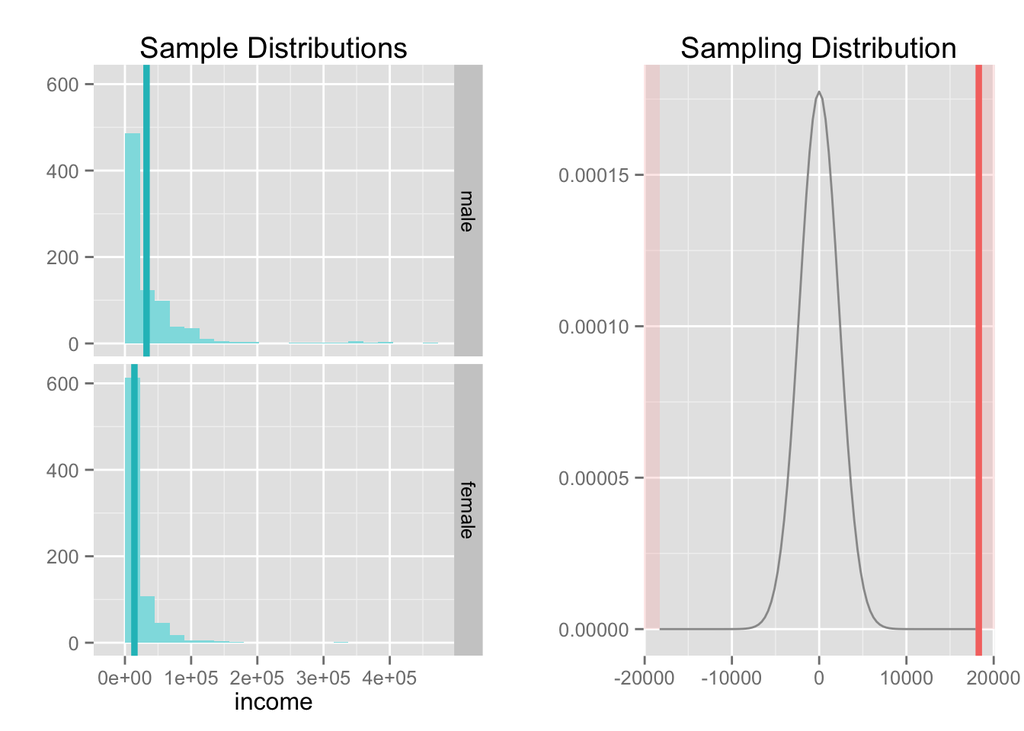

```
## $y_bar_diff
## [1] 18291.31
##
## $df
## [1] 800
##
## $SE
## [1] 2248.131
##
## $t
## [1] 8.1362
##
## $p_value
## [1] 0
```

```r
inference(data = acs, x = gender, y = income, type = "ht", null = 0,
          method = "theoretical", statistic = "mean", alternative = "twosided")
```

### Confounding variables

There is a clear difference between the average salaries of men and women, but could some, or all, of this difference be attributed to a variable other than gender? Remember that we call such variables confounding variables. We will evaluate whether `hrs_work` is a confounder for the relationship between gender and income. But before we do that, let’s first convert the `hrs_work` variable to a categorical variable (with levels `"full time"` or `"part time"`) so that we can use methods we have learned so far in the course to run the analysis. (Later in the course we will learn how to work with numerical explanatory variables in a regression model setting.)

### Recoding variables

We want to create a new variable, say `emp_type`, with levels `"full time"` or `"part time"` depending on whether the employee works 40 hours or more per week or less than 40 hours, respectively. Remember, we create a new variable with the mutate function.

```r
acs_emp <- acs_emp %>%
  mutate(emp_type = ifelse(hrs_work >= 40, "full time", "part time"))
```

The `ifelse()` function has three arguments: a logical test, return values for TRUE elements of test, and return values for FALSE elements of test. In this case, `emp_type` will be coded as `"full time"` for observations where `hrs_work` is greater than or equal to 40, and as `"part time"` otherwise.

To find out what percent of the sample is full vs. part time, we turn to summary statistics:

```r
acs_emp %>%
  group_by(emp_type) %>%
  summarise(time_prop = n() / nrow(acs_emp))
```

```
## Source: local data frame [2 x 2]
##
##    emp_type time_prop
##       (chr)     (dbl)
## 1 full time 0.7069988
## 2 part time 0.2930012
```

Here we first grouped the data by the new `emp_type` variable, and then we calculated proportions of full and part time employees by first counting how many there are in each group (`n()`) and then dividing this number by the total number of rows of the dataset.

1. Create a bar plot of the distribution of the `emp_type` variable, and also include the summary statistics you calculated above in your answer. What percent of the sample are full time and what percent are part time employees?

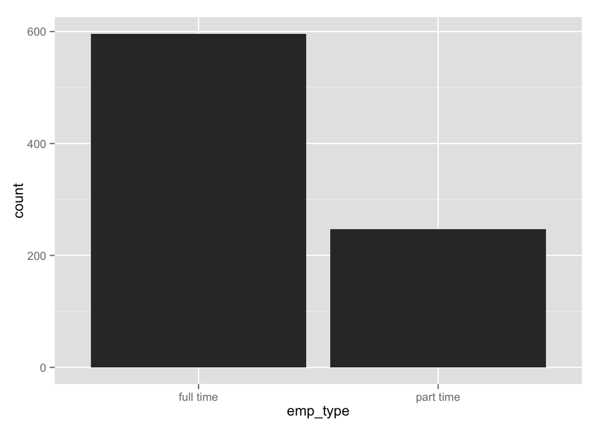

```r
qplot(data = acs_emp, x = emp_type, geom = "bar")
```

1. Are females more heavily represented among full time employees or part time employees? Answer this question using summary statistics (code provided below) and a visualization.

```r
acs_emp %>%
  group_by(emp_type, gender) %>%
  summarise(n())
```

```
## Source: local data frame [4 x 3]
## Groups: emp_type [?]
##
##    emp_type gender   n()
##       (chr) (fctr) (int)
## 1 full time   male   383
## 2 full time female   213
## 3 part time   male    87
## 4 part time female   160
```

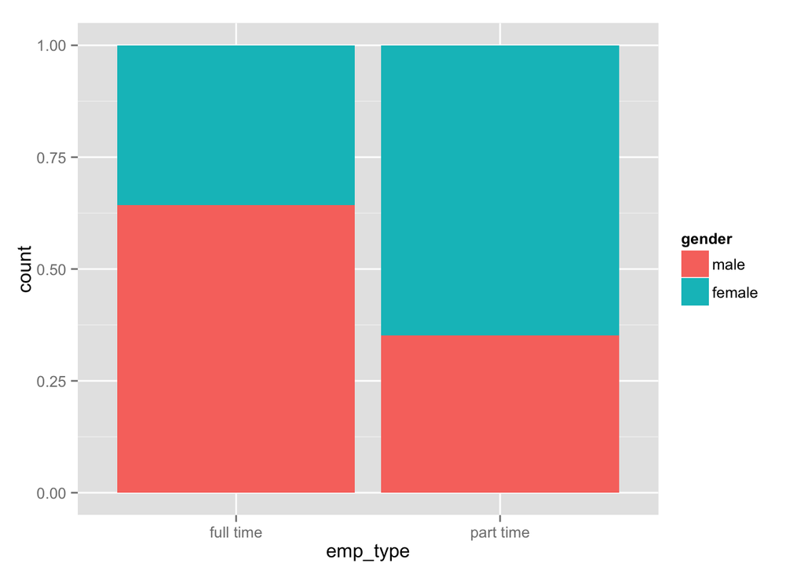

```r
qplot(data = acs_emp, x = emp_type, fill = gender, position = "fill")
```

## On your own

- Create two subsets of the `acs_emp` dataset: one for full time employees and one for part time employees. No interpretation is needed for this question, just the code is sufficient.

```r
acs_emp_ft <- acs_emp %>%
  filter(emp_type == "full time")

acs_emp_pt <- acs_emp %>%
  filter(emp_type == "part time")
```

- Use a hypothesis test to evaluate whether there is a difference in average incomes of **full time** male and female employees. If the difference is significant, also include a confidence interval (at the equivalent confidence level) estimating the magnitude of the average income difference.

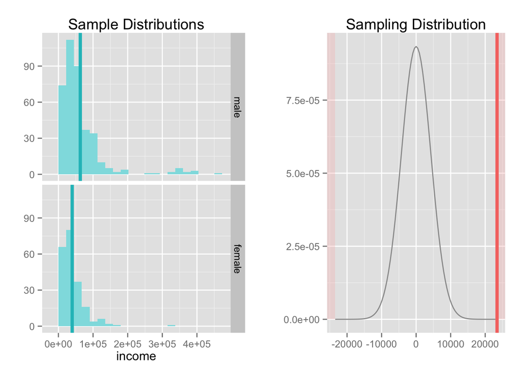

```
## $y_bar_diff
## [1] 23431.44
##
## $df
## [1] 212
##
## $SE
## [1] 4274.098
##
## $t
## [1] 5.4822
##
## $p_value
## [1] 0
```

```r
inference(data = acs_emp_ft, x = gender, y = income, type = "ht", null = 0,
          method = "theoretical", statistic = "mean", alternative = "twosided")
```

- Use a hypothesis test to evaluate whether there is a difference in average incomes of **part time** male and female employees. If the difference is significant, also include a confidence interval (at the equivalent confidence level) estimating the magnitude of the average income difference.

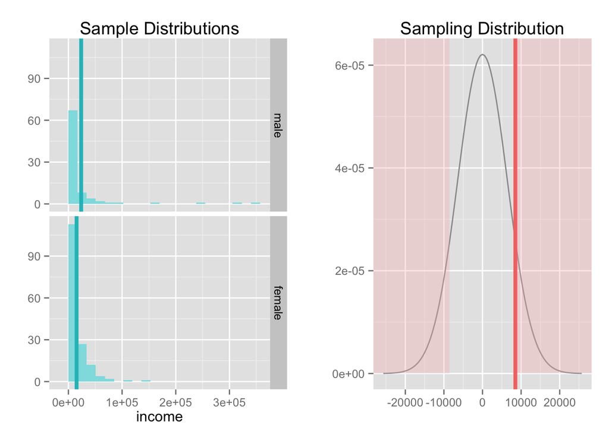

```
## $y_bar_diff
## [1] 8512.292
##
## $df
## [1] 86
##
## $SE
## [1] 6425.062
##
## $t
## [1] 1.3249
##
## $p_value
## [1] 0.1887
```

```r
inference(data = acs_emp_pt, x = gender, y = income, type = "ht", null = 0,
          method = "theoretical", statistic = "mean", alternative = "twosided")
```

- What do your findings from these hypothesis test suggest about whether or not working full or part time might be a confounding variable in the relationship between gender and income?
- What type of a test would we use to compare the average salaries across the various race / ethnicity groups in this dataset? Explain your reasoning.

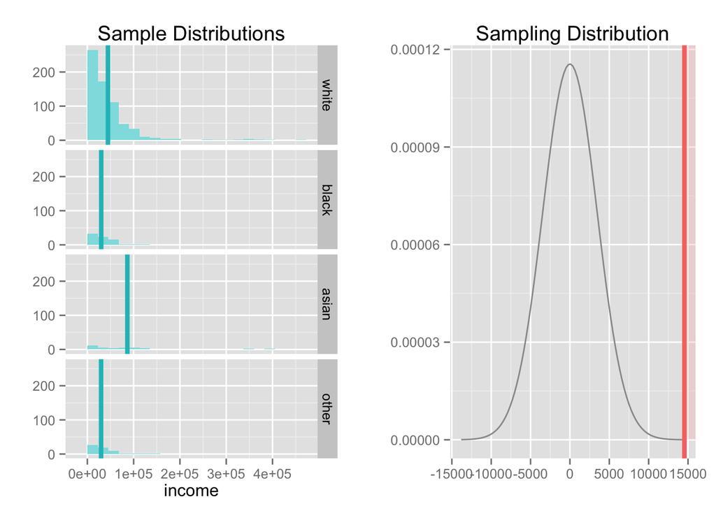

```
## $y_bar_diff
## [1] 14537.76
##
## $df
## [1] 75
##
## $SE
## [1] 3453.559
##
## $t
## [1] 4.2095
##
## $p_value
## [1] 0
```

```r
inference(data = acs_emp, x = race, y = income, type = "ht", null = 0,
          method = "theoretical", statistic = "mean", alternative = "greater")
```

- Conduct this hypothesis test using the `inference` function. Note that the response variable is `income` and the explanatory variable is `race`. You will need to figure out the remaining arguments for the function. Use a trial-and-error approach, and let the errors inform you as to what else needs to be specified, and how. (Note: Use the dataset containing records from all employes participants: `acs_emp`)
- Pick **another** numerical variable from the dataset to be your response variable, and also pick a categorical explanatory variable (can be one we used before). Conduct the appropriate hypothesis test, using the `inference` function, to compare means of the response variable across levels of the explanatory variable. Make sure to state your research question, and interpret your conclusion in context of the dataset. Note that you c can use the complete `acs` dataset, the subsetted `acs_emp` dataset, or another subset that you create.